# Practical Machine Learning Course Project

John Condon

September 19, 2016

## Project Overview

The goal of this project is to use data from sensors on the belt, forearm, arm, and dumbell of 6 participants to determine whether they are using proper form to lift a dumbell.

The Classe result feature has values A, B, C, D, and E. Class A corresponds to the correct execution of the exercise, while the other 4 classes correspond to common mistakes.

Data was recorded using inertial measurement units (IMU), providing three-axes acceleration, gyroscope and magnetometer data. Each IMU also featured a Bluetooth module that streamed the recorded data to a notebook lab computer. The sensors were mounted in the users’ glove, armband, lumbar belt and dumbbell (see left-hand figure), making the tracking system as unobtrusive as possible.

[figure not shown]

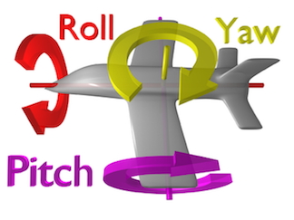

The right-hand figure illustrates the concepts of pitch, yaw, and roll, commonly used in aviation, that are part of the output from the sensors.

Participants performed one set of 10 repetitions of the Unilateral Dumbbell Biceps Curl in each of five different manners:

- Classe A - executed exactly as specified
- Classe B - elbows thrown to front
- Classe C - lifted only halfway
- Classe D - lowered only halfway
- Classe E - hips thrown to front

The original paper on which this project is based is available at: [Qualitative Activity Recognition of Weight Lifting Exercises](http://groupware.les.inf.puc-rio.br/public/papers/2013.Velloso.QAR-WLE.pdf)

## Project approach

Two different machine learning models were created: a Random Forest model, and a Support Vector Machine (SVM) model. These machine learning algorithms were selected because they are among the most popular and powerful for high dimension classification problems.

To allow an apples to apples comparison of the models, each model was trained using the same training partition and validated using the same validation data. Each model was run against the project test set and the results compared as well.

## Model Development and Evaluation

### Load required libraries

All the package libraries needed for the selected machine learning algorithms are first loaded into the environment.

### Prepare Project Data

#### Read and clean project data

The project training and testing data sets should be downloaded from the source urls to the project directory and then read as .csv files into R.

- https://d396qusza40orc.cloudfront.net/predmachlearn/pml-training.csv
- https://d396qusza40orc.cloudfront.net/predmachlearn/pml-testing.csv

```r
pmlTrain <- read.csv("./pml-training.csv")
pmlTest = read.csv("./pml-testing.csv")
```

The datasets contain 160 columns. The training dataset has 19622 rows and the test dataset has 20. The first 7 column attributes do not contain sensor measures, so they will be excluded as predictors. Column 160 is the target prediction variable, classe. Structural queries reveal that many columns are primarily NA’s. Also, some columns are integer and others numeric.

First, we’ll drop the first 7 columns and coerce all columns to numeric, with the exception of the classe column, 160.

```r
pmlTrain[,8:159] <-sapply(pmlTrain[,8:159], as.numeric)
pmlTest[,8:159] <-sapply(pmlTest[,8:159], as.numeric)

pmlTrain <- pmlTrain[,8:160]
pmlTest <- pmlTest[,8:160]
```

Next, we’ll eliminate the NA columns.

```r
# find NA columns
nas = is.na(apply(pmlTest[,-160], 2, sum))

# drop NA columns from both the training and test data sets
pmlTest <- pmlTest[, !nas]
pmlTrain <- pmlTrain[, !nas]
```

#### Parition train and validation datasets

The cleaned pmlTrain dataset was then partitioned into train and validation (val) datasets. Train was used in project training and val was used to estimate each model’s out of sample error.

```r
seed <- 415
set.seed(seed)

inTrain <- createDataPartition(y=pmlTrain$classe, p=0.7, list=FALSE);
train <- pmlTrain[inTrain,]
val <- pmlTrain[-inTrain,]
```

## Create and Evaluate Machine Learning Models

### Summary of model training feature set

52 predictor feature columns and the target variable Classe remain after dropping the columns that contained mostly missing data. The features that remain are the integrated intertial measures of pitch, yaw, roll, and total acceleration, and the detailed three-axes data from the accelerometer, gyro, and magnetometer for each of the arm, glove, belt, and dumbell sensors.

The machine learning models will be built based on this feature set.

#### Build Random Forest model

Random Forest was selected as one the machine learning techniques becasuse it is one of the most used and accurate machine learning algorithms.

Random forest works by extending bagging to classification trees. It is an ensemble model that works by growing a “forest” of many trees. Each tree is grown on a bootstrap sample, with replacement, of the full set of training data. At each node, each tree selects a random subset of all the possible variables from the training data. It then finds the best split on the selected variables. Predictions are based on a vote of all the final trees.

```r
### randomforest with cross-validation

fit.ctrl <- trainControl(method="cv",number=5)
fit.rf <- train(classe ~ ., data=train, method="rf",prox=T,
                     importance=TRUE, ntree=100, trainControl=fit.ctrl)
```

#### Evaluate Random Forest model

```r
# print model results

print(fit.rf)
```

```
## Random Forest
##
## 13737 samples
##    52 predictor
##     5 classes: 'A', 'B', 'C', 'D', 'E'
##
## No pre-processing
## Resampling: Bootstrapped (25 reps)
## Summary of sample sizes: 13737, 13737, 13737, 13737, 13737, 13737, ...
## Resampling results across tuning parameters:
##
##   mtry  Accuracy   Kappa
##    2    0.9878630  0.9846489
##   27    0.9885723  0.9855476
##   52    0.9807036  0.9755965
##
## Accuracy was used to select the optimal model using  the largest value.
## The final value used for the model was mtry = 27.
```

```r
# print final model results

print(fit.rf$finalModel)
```

```
##
## Call:
##  randomForest(x = x, y = y, ntree = 100, mtry = param$mtry, importance = TRUE,      proximity = ..1, trainControl = ..4)
##                Type of random forest: classification
##                      Number of trees: 100
## No. of variables tried at each split: 27
##
##         OOB estimate of  error rate: 0.6%
## Confusion matrix:
##      A    B    C    D    E  class.error
## A 3903    2    0    0    1 0.0007680492
## B   18 2633    6    1    0 0.0094055681
## C    0   16 2374    6    0 0.0091819699
## D    0    1   19 2231    1 0.0093250444
## E    0    1    2    8 2514 0.0043564356
```

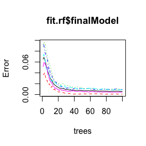

```r
# print the plot showing the number of trees used in the final model

plot(fit.rf$finalModel)
```

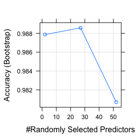

```r
# show the plot of decreasing variable importance

plot(fit.rf)
```

##### Expected Out of Sample Error

```r
# Evaluate the model against new data using the validation dataset, val.
# Print a confusion matrix to show the accuracy of the val classe predictions.

p.val <- predict(fit.rf, val)
confusion.val.rf <- confusionMatrix(val$classe, p.val)
confusion.val.rf
```

```
## Confusion Matrix and Statistics
##
##           Reference
## Prediction    A    B    C    D    E
##          A 1671    2    1    0    0
##          B    5 1127    6    1    0
##          C    0    3 1021    2    0
##          D    0    1    9  954    0
##          E    0    0    5    5 1072
##
## Overall Statistics
##
##                Accuracy : 0.9932
##                  95% CI : (0.9908, 0.9951)
##     No Information Rate : 0.2848
##     P-Value [Acc > NIR] : < 2.2e-16
##
##                   Kappa : 0.9914
##  Mcnemar's Test P-Value : NA
##
## Statistics by Class:
##
##                      Class: A Class: B Class: C Class: D Class: E
## Sensitivity            0.9970   0.9947   0.9798   0.9917   1.0000
## Specificity            0.9993   0.9975   0.9990   0.9980   0.9979
## Pos Pred Value         0.9982   0.9895   0.9951   0.9896   0.9908
## Neg Pred Value         0.9988   0.9987   0.9957   0.9984   1.0000
## Prevalence             0.2848   0.1925   0.1771   0.1635   0.1822
## Detection Rate         0.2839   0.1915   0.1735   0.1621   0.1822
## Detection Prevalence   0.2845   0.1935   0.1743   0.1638   0.1839
## Balanced Accuracy      0.9982   0.9961   0.9894   0.9948   0.9990
```

Out of sample error for the random forest model was estimated by applying the prediction algorithm to new data using the validation data set val. The confusion matrix of the actual classe value for each sample row and the predicted value showed an overall accuracy of 0.9932 with a 95% Confidence Interval (CI).

The following plot shows that the random forest model had excellent sensitivity and selectivity for the 5 values of classe.

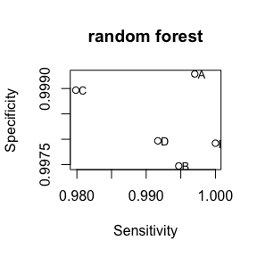

#### Predictor Importance

This table compares the top 5 predictors for each of classe, A to E. It is interesting to take classe A, entirely correct execution, as a benchmark. All but one of four incorrect forms agree with A on the most important predictor, roll_belt. For predictor 2, only 2 of 4 agree. For predictors 3 and 4, none agree. All classes agree that total_accel_belt is the fifth most important predictor. Also noteworthy is that all the classes use the same set of 5 predictor features that classe A uses, but each with a distinct order of importance. This suggests that these are really the best set of differentiators among the five classes of performing the biceps curl.

Top 5 Predictors by Classe

| classe | 1 | 2 | 3 | 4 | 5 |
| --- | --- | --- | --- | --- | --- |
| A | roll_belt | yaw_belt | gyros_belt_x | pitch_belt | total_accel_belt |
| B | pitch_belt | roll_belt | yaw_belt | gyros_belt_x | total_accel_belt |
| C | roll_belt | yaw_belt | pitch_belt | gyros_belt_x | total_accel_belt |
| D | roll_belt | yaw_belt | pitch_belt | gyros_belt_x | total_accel_belt |
| E | roll_belt | pitch_belt | yaw_belt | gyros_belt_x | total_accel_belt |

### Model II: Classification Support Vector Machine (SVM)

#### Build SVM model

Support Vector Machines (SVM) provide a powerful technique for general classification. SVMs were originally developed for binary classification, where sample data falls into two distinct classes. In the multidimensional space defined by the feature variables, the SVM looks for the optimal separating hyperplane between the two classes by maximizing the margin between the classes’ closest points. The points lying on the boundaries are called support vectors, and the middle of the margin is the optimal separating hyperplane.

Our model must deal with a multi-class classification of the set of 5 classe variables A to E. While SVMs bsically are designed for binary clasification problems, they can deal with this problem by fitting all binary subclassifiers and then voting to determine the correct class.

When the data is nonlinear and there is no linear separator, the data points are projected onto a higher-dimensional space by what is called a kernal, where the data points effectively become linearly separable.

[see “Support Vector Machines” by David Meyer] (https://cran.r-project.org/web/packages/e1071/vignettes/svmdoc.pdf)

##### SVM Parameter Selection

The SVM model uses the default Radial kernal. It has two parameters which determine the accuracy of the resulting SVM model. The first is gamma, and the second is cost.

I used tune.svm to find the optimal values for gamma and cost. tune.svm performs a grid search over all parameters in the specified ranges, and returns the best performing values based on accuracy. I did two rounds of tune.svm, using the first round to narrow in on the optimal range, and the second to find the best paramater values for gamma and cost. The final values were gamma=0.06, and cost=256.

The cross parameter was set to 10, which specified using 10-fold cross validation.

```r
set.seed(seed)

# obj <- tune.svm(classe ~ ., data=train,
#       gamma = 2^(-2:2), cost = 2^(2:4))

# obj.2 <- tune.svm(classe ~ ., data=train,
#       gamma = seq(0.01,0.5, by= 0.05), cost = 2^(2:8))


fit.svm <- svm(classe ~ ., data=train,
            cost=256, gamma=0.06, cross=10)
```

#### Evaluate SVM model

```r
print(fit.svm)
```

```
##
## Call:
## svm(formula = classe ~ ., data = train, cost = 256, gamma = 0.06,
##     cross = 10)
##
##
## Parameters:
##    SVM-Type:  C-classification
##  SVM-Kernel:  radial
##        cost:  256
##       gamma:  0.06
##
## Number of Support Vectors:  5083
```

```r
print(fit.svm$tot.accuracy)
```

```
## [1] 99.43219
```

The svm modeled created 5083 support vectors and achieved an overall accuracy of 0.9943 against the training data.

##### Expected Out of Sample Error

```r
svm.predict.val <- predict(fit.svm, val[-53])
confusion.svm.val <- confusionMatrix(val$classe, svm.predict.val)
confusion.svm.val
```

```
## Confusion Matrix and Statistics
##
##           Reference
## Prediction    A    B    C    D    E
##          A 1672    1    0    0    1
##          B    1 1137    1    0    0
##          C    0    1 1021    4    0
##          D    0    0    8  952    4
##          E    0    0    2    3 1077
##
## Overall Statistics
##
##                Accuracy : 0.9956
##                  95% CI : (0.9935, 0.9971)
##     No Information Rate : 0.2843
##     P-Value [Acc > NIR] : < 2.2e-16
##
##                   Kappa : 0.9944
##  Mcnemar's Test P-Value : NA
##
## Statistics by Class:
##
##                      Class: A Class: B Class: C Class: D Class: E
## Sensitivity            0.9994   0.9982   0.9893   0.9927   0.9954
## Specificity            0.9995   0.9996   0.9990   0.9976   0.9990
## Pos Pred Value         0.9988   0.9982   0.9951   0.9876   0.9954
## Neg Pred Value         0.9998   0.9996   0.9977   0.9986   0.9990
## Prevalence             0.2843   0.1935   0.1754   0.1630   0.1839
## Detection Rate         0.2841   0.1932   0.1735   0.1618   0.1830
## Detection Prevalence   0.2845   0.1935   0.1743   0.1638   0.1839
## Balanced Accuracy      0.9995   0.9989   0.9942   0.9951   0.9972
```

Out of sample error for the svm was estimated by applying the prediction algorithm to new data using the validation data set. The confusion matrix of the actual classe value for each sample row and the predicted value showed an overall accuracy of 0.9956 with a 95% Confidence Interval (CI).

The following plot shows that the svm model also had excellent sensitivity and selectivity for the 5 values of classe.

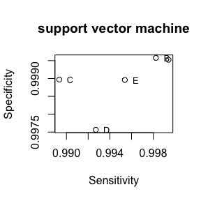

#### Predictor Importance

Unlike the random forest model, the svm does not rank the importance of the model predictors.

## Project Summary - Random Forest vs. SVM

Both the random forest and the svm models were extremely accurate. The random forest model had an overall out of sample accuracy of 0.9932, while the svm model had an overall out of sample accuracy of 0.9956, both with a 95% Confidence Interval (CI).

Both models had excellent sensitivity and selectivity for the different classes, each in the range of 0.99.

Both models also correctly predicted 20 out of 20 of the project test cases.

The random forest and svm models were chosen for the project because of their strength in handling large multi-class classification problems. They appear to heve been equally effective in this project.